# Lab 4_Demo

2024-04-22

This data set includes more possible predictors than the text alone, but for this model we will only use the text variable

```r
urlfile ="https://raw.githubusercontent.com/MaRo406/EDS-231-text-sentiment/main/data/climbing_reports_model_dat.csv"
incidents_df<-readr::read_csv(url(urlfile))
```

Now we’ll split our data into training and test portions

```r
set.seed(1234)

incidents2class <- incidents_df %>%
  mutate(fatal = factor(if_else(
                        is.na(Deadly),
                        "non-fatal", "fatal")))


incidents_split <- initial_split(incidents2class, strata = fatal)

incidents_train <- training(incidents_split)
incidents_test <- testing(incidents_split)
```

We use recipe() to specify the predictor and outcome variables and the data.

```r
incidents_rec <- recipe(fatal ~ Text, data = incidents_train)
```

Next we add some familiar pre-processing steps on our Text variable: tokenize to word level, filter to the most common words, and calculate tf-idf.

```r
recipe <- incidents_rec %>%
  step_tokenize(Text) %>%
  step_tokenfilter(Text, max_tokens = 1000) %>%
  step_tfidf(Text)
```

Create tidymodels workflow to combine the modeling components

```r
incidents_wf <- workflow() %>%
  add_recipe(recipe)
```

```r
nb_spec <- naive_Bayes() %>%
  set_mode("classification") %>%
  set_engine("naivebayes")

nb_spec
```

```
## Naive Bayes Model Specification (classification)
##
## Computational engine: naivebayes
```

Now we are ready to add our model to the workflow and fit it to the training data

```r
nb_fit <- incidents_wf %>%
  add_model(nb_spec) %>%
  fit(data = incidents_train)
```

Next up is model evaluation. We’ll stretch our training data further and use resampling to evaluate our naive Bayes model. Here we create 10-fold cross-validation sets, and use them to estimate performance.

```r
set.seed(999)
incidents_folds <- vfold_cv(incidents_train)

incidents_folds
```

```
## #  10-fold cross-validation
## # A tibble: 10 × 2
##    splits             id
##    <list>             <chr>
##  1 <split [1869/208]> Fold01
##  2 <split [1869/208]> Fold02
##  3 <split [1869/208]> Fold03
##  4 <split [1869/208]> Fold04
##  5 <split [1869/208]> Fold05
##  6 <split [1869/208]> Fold06
##  7 <split [1869/208]> Fold07
##  8 <split [1870/207]> Fold08
##  9 <split [1870/207]> Fold09
## 10 <split [1870/207]> Fold10
```

```r
  nb_wf <- workflow() %>%
    add_recipe(recipe) %>%
    add_model(nb_spec)

  nb_wf
```

```
## ══ Workflow ════════════════════════════════════════════════════════════════════
## Preprocessor: Recipe
## Model: naive_Bayes()
##
## ── Preprocessor ────────────────────────────────────────────────────────────────
## 3 Recipe Steps
##
## • step_tokenize()
## • step_tokenfilter()
## • step_tfidf()
##
## ── Model ───────────────────────────────────────────────────────────────────────
## Naive Bayes Model Specification (classification)
##
## Computational engine: naivebayes
```

To estimate its performance, we fit the model to each of the resampled folds, and then evaluate on the heldout part of each resampled fold.

```r
nb_rs <- fit_resamples(
  nb_wf,
  incidents_folds,
  control = control_resamples(save_pred = T)
)
```

Extract the relevant information using collect_metrics() and collect_predictions() and examine the performance metrics.

```r
nb_rs_metrics <- collect_metrics(nb_rs)
nb_rs_predictions <- collect_predictions(nb_rs)

nb_rs_metrics
```

```
## # A tibble: 3 × 6
##   .metric     .estimator  mean     n std_err .config
##   <chr>       <chr>      <dbl> <int>   <dbl> <chr>
## 1 accuracy    binary     0.797    10 0.00944 Preprocessor1_Model1
## 2 brier_class binary     0.202    10 0.00939 Preprocessor1_Model1
## 3 roc_auc     binary     0.725    10 0.0132  Preprocessor1_Model1
```

We’ll use two performance metrics: accuracy and ROC AUC. Accuracy is the proportion of the data that is predicted correctly. The ROC curve plots the true positive rate against the false positive rate; AUC closer to 1 indicates a better-performing model, while AUC closer to 0.5 indicates a model that does no better than random guessing.

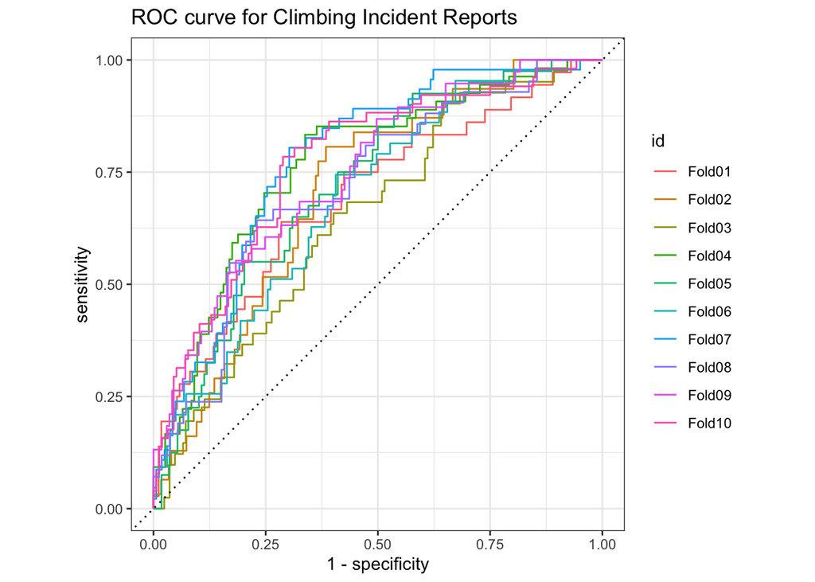

```r
nb_rs_predictions %>%
  group_by(id) %>%
  roc_curve(truth = fatal, .pred_fatal) %>%
  autoplot() +
  labs(title = "ROC curve for Climbing Incident Reports")
```

Another model method involves the confusion matrix. A confusion matrix tabulates a model’s false positives and false negatives for each class.

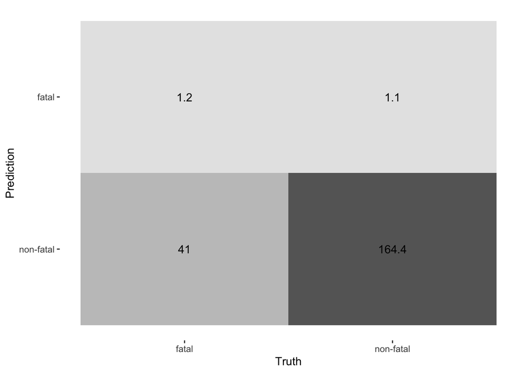

```r
conf_mat_resampled(nb_rs, tidy = F) %>%
  autoplot(type = "heatmap")
```

Let’s move up to a more sophisticated model. Recall that lasso classification model uses regularization on regression to help us choose a simpler, more generalizable model. Variable selection helps us identify which features to include in our model.

Lasso classification learns how much of a penalty to put on features to reduce the high-dimensional space of original possible variables (tokens) for the final model.

```r
lasso_spec <- logistic_reg(penalty = 0.01, mixture = 1) %>%
  set_mode("classification") %>%
  set_engine("glmnet")
```

```r
lasso_wf <- workflow() %>%
  add_model(lasso_spec) %>%
  add_recipe(recipe)
```

```r
set.seed(123)

lasso_rs <- fit_resamples(
  lasso_wf,
  incidents_folds,
  control = control_resamples(save_pred = T)
)

lasso_rs_metrics <- collect_metrics(lasso_rs)

lasso_rs_metrics
```

```
## # A tibble: 3 × 6
##   .metric     .estimator   mean     n std_err .config
##   <chr>       <chr>       <dbl> <int>   <dbl> <chr>
## 1 accuracy    binary     0.896     10 0.00849 Preprocessor1_Model1
## 2 brier_class binary     0.0732    10 0.00398 Preprocessor1_Model1
## 3 roc_auc     binary     0.945     10 0.00781 Preprocessor1_Model1
```

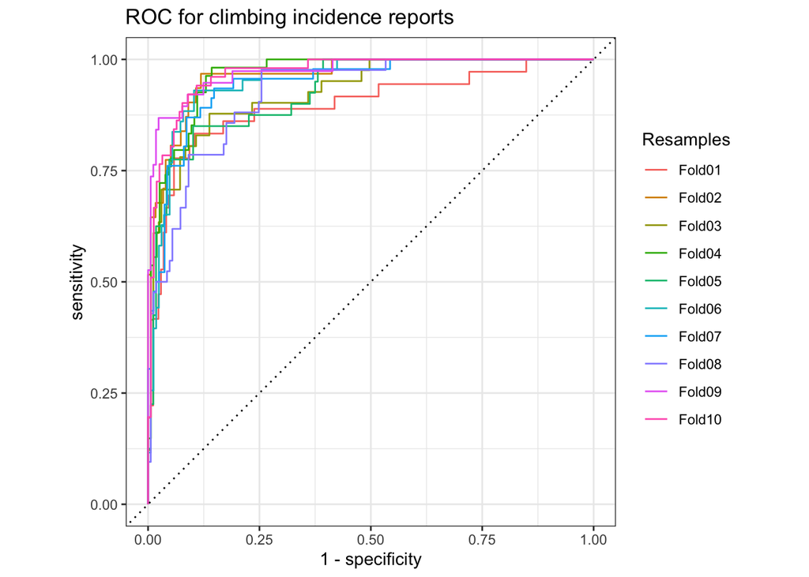

```r
lasso_rs_predictions <- collect_predictions(lasso_rs) %>%
  group_by(id) %>%
  roc_curve(truth = fatal, .pred_fatal) %>%
  autoplot() +
  labs(
    color = "Resamples",
    title = "ROC for climbing incidence reports"
  )

lasso_rs_predictions
```

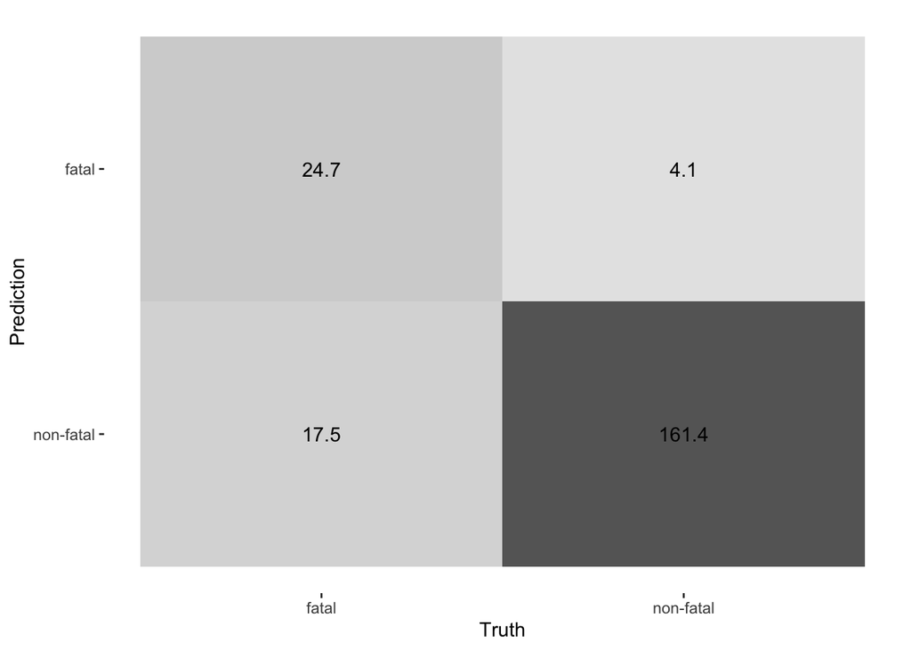

```r
conf_mat_resampled(lasso_rs, tidy = F) %>%
  autoplot(type = "heatmap")
```

Recall that the penalty is a model hyperparameter (lambda). The higher it is, the more model coefficients are reduced (sometimes to 0, removing them – feature selection). We set it manually before, but we can also estimate its best value, again by training many models on resampled data sets and examining their performance.

```r
tune_spec <- logistic_reg(penalty = tune(), mixture = 1) %>%
  set_mode("classification") %>%
  set_engine("glmnet")
```

```r
lambda_grid <- grid_regular(
  penalty(),
  levels = 30
)

lambda_grid
```

```
## # A tibble: 30 × 1
##     penalty
##       <dbl>
##  1 1   e-10
##  2 2.21e-10
##  3 4.89e-10
##  4 1.08e- 9
##  5 2.40e- 9
##  6 5.30e- 9
##  7 1.17e- 8
##  8 2.59e- 8
##  9 5.74e- 8
## 10 1.27e- 7
## # ℹ 20 more rows
```

Here we use grid_regular() to create 30 possible values for the regularization penalty. Then tune_grid() fits a model at each of those values.

```r
tune_wf  <- workflow() %>%
  add_recipe(recipe) %>%
  add_model(tune_spec)

set.seed(2023)
tunes_rs <- tune_grid(
  tune_wf,
  incidents_folds,
  grid = lambda_grid,
  control = control_resamples(save_pred = T)
)
```

```r
collect_metrics(tunes_rs)
```

```
## # A tibble: 90 × 7
##     penalty .metric     .estimator  mean     n std_err .config
##       <dbl> <chr>       <chr>      <dbl> <int>   <dbl> <chr>
##  1 1   e-10 accuracy    binary     0.882    10 0.00670 Preprocessor1_Model01
##  2 1   e-10 brier_class binary     0.104    10 0.00588 Preprocessor1_Model01
##  3 1   e-10 roc_auc     binary     0.917    10 0.00988 Preprocessor1_Model01
##  4 2.21e-10 accuracy    binary     0.882    10 0.00670 Preprocessor1_Model02
##  5 2.21e-10 brier_class binary     0.104    10 0.00588 Preprocessor1_Model02
##  6 2.21e-10 roc_auc     binary     0.917    10 0.00988 Preprocessor1_Model02
##  7 4.89e-10 accuracy    binary     0.882    10 0.00670 Preprocessor1_Model03
##  8 4.89e-10 brier_class binary     0.104    10 0.00588 Preprocessor1_Model03
##  9 4.89e-10 roc_auc     binary     0.917    10 0.00988 Preprocessor1_Model03
## 10 1.08e- 9 accuracy    binary     0.882    10 0.00670 Preprocessor1_Model04
## # ℹ 80 more rows
```

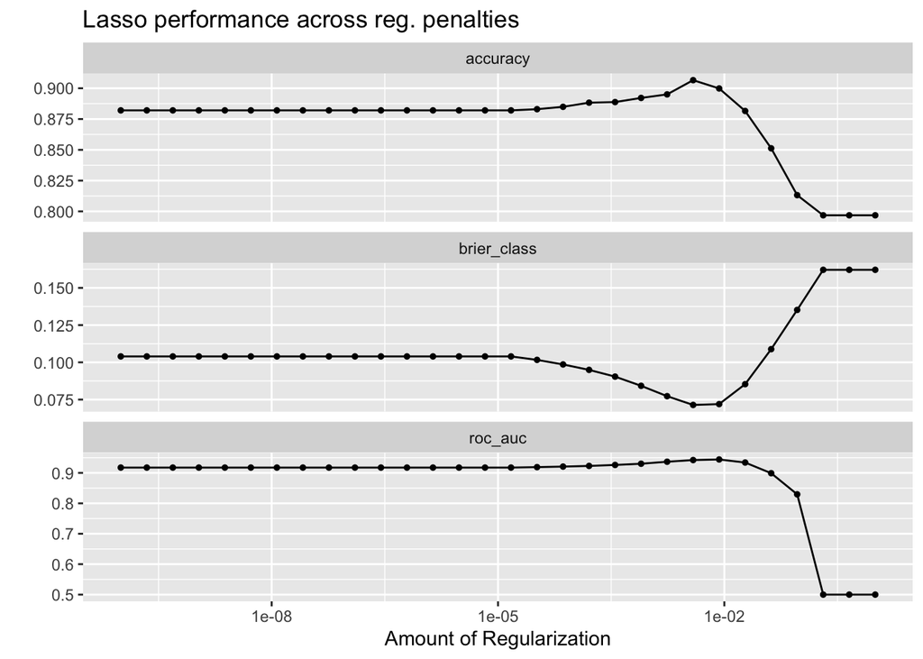

```r
autoplot(tunes_rs) +
  labs(
    title = "Lasso performance across reg. penalties"
  )
```

```r
tunes_rs %>%
  show_best(metric = "roc_auc")
```

```
## # A tibble: 5 × 7
##    penalty .metric .estimator  mean     n std_err .config
##      <dbl> <chr>   <chr>      <dbl> <int>   <dbl> <chr>
## 1 0.00853  roc_auc binary     0.944    10 0.00737 Preprocessor1_Model24
## 2 0.00386  roc_auc binary     0.942    10 0.00783 Preprocessor1_Model23
## 3 0.00174  roc_auc binary     0.937    10 0.00782 Preprocessor1_Model22
## 4 0.0189   roc_auc binary     0.934    10 0.00734 Preprocessor1_Model25
## 5 0.000788 roc_auc binary     0.930    10 0.00886 Preprocessor1_Model21
```

```r
tunes_rs %>%
  show_best(metric = "accuracy")
```

```
## # A tibble: 5 × 7
##    penalty .metric  .estimator  mean     n std_err .config
##      <dbl> <chr>    <chr>      <dbl> <int>   <dbl> <chr>
## 1 0.00386  accuracy binary     0.907    10 0.00804 Preprocessor1_Model23
## 2 0.00853  accuracy binary     0.900    10 0.00771 Preprocessor1_Model24
## 3 0.00174  accuracy binary     0.895    10 0.00818 Preprocessor1_Model22
## 4 0.000788 accuracy binary     0.892    10 0.00851 Preprocessor1_Model21
## 5 0.000356 accuracy binary     0.889    10 0.00748 Preprocessor1_Model20
```

```r
chosen_auc <- tunes_rs %>%
  select_by_one_std_err(metric = "roc_auc", -penalty)
```

OK, our tuning results have identified the best regularization penalty. Let’s finalize our workflow with it.

```r
final_lasso <- finalize_workflow(tune_wf, chosen_auc)

final_lasso
```

```
## ══ Workflow ════════════════════════════════════════════════════════════════════
## Preprocessor: Recipe
## Model: logistic_reg()
##
## ── Preprocessor ────────────────────────────────────────────────────────────────
## 3 Recipe Steps
##
## • step_tokenize()
## • step_tokenfilter()
## • step_tfidf()
##
## ── Model ───────────────────────────────────────────────────────────────────────
## Logistic Regression Model Specification (classification)
##
## Main Arguments:
##   penalty = 0.00853167852417281
##   mixture = 1
##
## Computational engine: glmnet
```

The penalty argument value now reflects our tuning result. Now we fit to our training data.

```r
fitted_lasso <- fit(final_lasso, incidents_train)
```

```r
fitted_lasso %>%
  extract_fit_parsnip() %>%
  tidy() %>%
  arrange(estimate)
```

```
## # A tibble: 1,001 × 3
##    term                 estimate penalty
##    <chr>                   <dbl>   <dbl>
##  1 tfidf_Text_died        -277.  0.00853
##  2 tfidf_Text_body        -158.  0.00853
##  3 tfidf_Text_death       -132.  0.00853
##  4 tfidf_Text_fatal        -76.8 0.00853
##  5 tfidf_Text_breathing    -47.7 0.00853
##  6 tfidf_Text_past         -32.5 0.00853
##  7 tfidf_Text_observed     -32.5 0.00853
##  8 tfidf_Text_occurred     -31.7 0.00853
##  9 tfidf_Text_noticed      -31.1 0.00853
## 10 tfidf_Text_either       -31.0 0.00853
## # ℹ 991 more rows
```

```r
fitted_lasso
```

```
## ══ Workflow [trained] ══════════════════════════════════════════════════════════
## Preprocessor: Recipe
## Model: logistic_reg()
##
## ── Preprocessor ────────────────────────────────────────────────────────────────
## 3 Recipe Steps
##
## • step_tokenize()
## • step_tokenfilter()
## • step_tfidf()
##
## ── Model ───────────────────────────────────────────────────────────────────────
##
## Call:  glmnet::glmnet(x = maybe_matrix(x), y = y, family = "binomial",      alpha = ~1)
##
```

[output cut: 50 more lines]

Finally, let’s fit to the test data and see how we did.

```r
last_fit(final_lasso, incidents_split) %>%
  collect_metrics()
```

```
## # A tibble: 3 × 4
##   .metric     .estimator .estimate .config
##   <chr>       <chr>          <dbl> <chr>
## 1 accuracy    binary        0.916  Preprocessor1_Model1
## 2 roc_auc     binary        0.951  Preprocessor1_Model1
## 3 brier_class binary        0.0635 Preprocessor1_Model1
```